# Manejo de rutas del sistema: O

En este momento ya hemos identificado como las rutas del sistema operativo van a interferir en como podemos leer los datos, o como podemos realizar acciones sobre ellos y no solo eso sino que también donde donde tenemos posicionados los archivos afectará la ejecución de ellas.

En las siguientes clases vamos a resolver el siguiente problema:

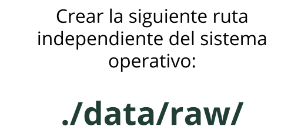

En el que enlistaremos los archivos y su contenido, independientemente del Sistema Operativo, de donde nos encontremos etc.

## Manejo de rutas

El primer manejador de rutas se llama OS, el cual es un modulo de Python que ya viene preinstalado en Python.

### Empecemos

Siempre debemos asegurarnos que estamos trabajando en el ambiente correcto, entonces en VSCode siempre debemos escoger el Kernel adecuado.

Recordemos la meto que es crear la ruta `./data/raw/` independiente del sistema. Pero primero corramos el siguiente comando `import os`

```python
import os
```

Ya se ha importado, ¿ahora que sigue?

**¿donde estoy parado?** con el comando `os.getcwd()` **significa get current work directory**.

```python
os.getcwd()
```

```
'/home/dens/Dens/Codes/Configuracion_profesional_Entorno/codes'
```

Podría almacenarlo en una variable llamada `CURRENT_DIR`.

```python
CURRENT_DIR = os.getcwd()
```

Ahora lo que yo quiero hacer es acceder a la carpeta de datos, entonces de alguna manera necesito retroceder directorios y también ir a otros. Para eso usaré el modulo de Python llamado `path` y `join`.

Lo que me ayudará a unir diferentes rutas. También usaremos la instrucción `os.pardir` que significa parent directory.

En el contexto de sistemas de archivos y programación, “parent dir” es una abreviatura de “parent directory” o “directorio padre”. Es el directorio que contiene el directorio actual.

Por ejemplo, si estás en el directorio `/home/user/documents`, el directorio padre sería `/home/user`.

```python
os.path.join(CURRENT_DIR,os.pardir)
```

```
'/home/dens/Dens/Codes/Configuracion_profesional_Entorno/codes/..'
```

Los 2 puntos significan un directorio atrás. ¿Entonces que necesitamos? una vez que retrocedemos después tenemos que acceder a `data` y luego a `raw`, corrí el comando en otro entorno donde tengo el proyecto, así que copie el resultado y lo colocare abajo.

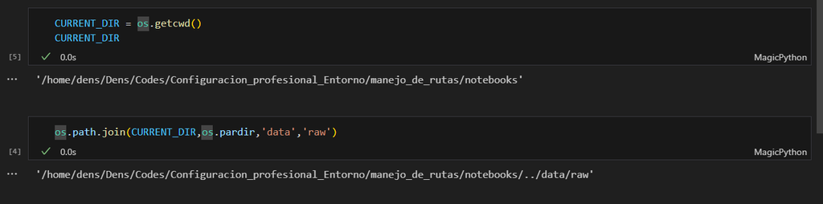

Y así tengo el proyecto organizado:

[figure not shown]

Así el resultado de llegar a la carpeta independientemente del sistema operativo, nos ayudará a manejar de manera eficiente el flujo de carpetas. También podemos verificar si un directorio existe.

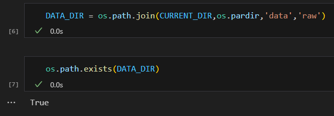

Ahora si yo quisiera saber si es un archivo, link, directorio o si es un disco que esta montado.

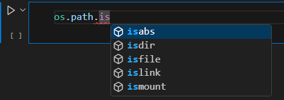

Veamos si `DATA_DIR` es un directorio:

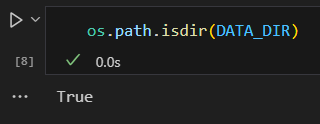

Para poder iterar sobre un directorio hacemos `os.listdir(directorio)`

Veamos un ejemplo para iterar sobre un archivo

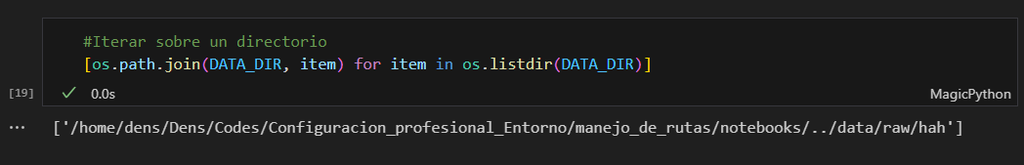

También podríamos crear nuevas carpetas con `os.mkdir(os.path.join(DATA_DIR,'OS'))`

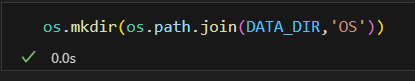

Y nos creo una nueva carpeta.

[figure not shown]

Aporte de **jhon freddy tavera blandon**

El manejo de rutas del sistema es esencial para trabajar con archivos y directorios en un programa. El módulo osen Python proporciona funciones para interactuar con el sistema operativo, incluida la manipulación de rutas de manera efectiva y portátil.

### Obtener la Ruta Actual:

Puedes usar `os.getcwd()` para obtener la ruta absoluta del directorio actual.

```
import os

current_dir = os.getcwd()
print("Directorio actual:", current_dir)
```

### Unir Rutas:

`os.path.join()` te permite unir partes de rutas en una ruta única y válida compatible con el sistema.

```
path = os.path.join("carpeta", "subcarpeta", "archivo.txt")
print("Ruta unida:", path)
```

### Obtener Nombre de Archivo y Directorio Base:

`os.path.basename()` devuelve el nombre del archivo de una ruta y os.path.dirname()devuelve el directorio base.

```
ruta = "/ruta/carpeta/archivo.txt"
nombre_archivo = os.path.basename(ruta)
directorio_base = os.path.dirname(ruta)

print("Nombre de archivo:", nombre_archivo)
print("Directorio base:", directorio_base)
```

### Dividir Ruta en Directorio y Nombre de Archivo:

`os.path.split()` divide una ruta en el directorio base y el nombre de archivo.

```
ruta = "/ruta/carpeta/archivo.txt"
directorio, nombre_archivo = os.path.split(ruta)

print("Directorio:", directorio)
print("Nombre de archivo:", nombre_archivo)
```

#### Verificar si existe una ruta:

`os.path.exists()` comprueba si existe una ruta dada en el sistema.

```
ruta = "/ruta/carpeta/archivo.txt"
if os.path.exists(ruta):
    print("La ruta existe")
else:
    print("La ruta no existe")
```

### Crear directorios anidados:

`os.makedirs()` crea directorios anidados en una ruta dada.

```
nueva_ruta = "/nuevo/directorio/anidado"
os.makedirs(nueva_ruta)
```

#### Listar Archivos en un Directorio:

`os.listdir()` devuelve una lista de nombres de archivos y carpetas en un directorio.

```
directorio = "/ruta/del/directorio"
archivos = os.listdir(directorio)
print("Archivos en el directorio:", archivos)
```

### Verificar si es Archivo o Directorio:

`os.path.isfile()` verifica si una ruta dada es un archivo, y `os.path.isdir()` verifica si es un directorio.

```
ruta = "/ruta/carpeta"
if os.path.isdir(ruta):
    print("Es un directorio")
elif os.path.isfile(ruta):
    print("Es un archivo")
else:
    print("No es un archivo ni un directorio")
```

### Cambiar el Directorio Actual:

`os.chdir()` cambia el directorio actual.

```
nuevo_directorio = "/nuevo/directorio"
os.chdir(nuevo_directorio)
```

### Eliminar un Archivo o Directorio:

`os.remove()` eliminar un archivo, y os.rmdir()eliminar un directorio vacío.

```
archivo_a_eliminar = "/ruta/archivo_a_eliminar.txt"
os.remove(archivo_a_eliminar)

directorio_a_eliminar = "/ruta/directorio_a_eliminar"
os.rmdir(directorio_a_eliminar)
```

Estos son solo algunos ejemplos de cómo puedes utilizar el módulo osen Python para manejar rutas del sistema

## Documentación:

[Pathname manipulations](https://docs.python.org/3/library/os.path.html)